# Projeto Machine Learning

Arthur Henrique Elias de Lima

# Primeira questão

```r
# Carrega todas as bibliotecas necessárias
pacotes <- c("tidymodels", "rpart", "rpart.plot", "glue", "dplyr", "ggplot2", "patchwork","parsnip")

# Instala os pacotes que não estão instalados
pacotes_nao_instalados <- pacotes[!(pacotes %in% installed.packages()[,"Package"])]
if(length(pacotes_nao_instalados) > 0) {
  install.packages(pacotes_nao_instalados)
}

# Carrega as bibliotecas
lapply(pacotes, library, character.only = TRUE)
```

```
## • Dig deeper into tidy modeling with R at https://www.tmwr.org
```

[output not shown]

[output cut: 47 more lines]

```r
tidymodels::tidymodels_prefer()
```

```r
setwd("E:/Downloads/Projeto")
saude=read.csv("diabetes_test.csv")
saude$Resultado= factor(saude$Resultado,levels = c("1","0"), labels = c("Diabetico", "normal"))
```

```r
splitted <- initial_split(saude, prop = 0.80, strata = Resultado)
treinamento <- training(splitted)
teste <- testing(splitted)
```

```r
receita <- recipe(Resultado ~ ., data = treinamento) %>%
  recipes::step_dummy(all_nominal(), -all_outcomes()) %>%
  recipes::step_zv(all_numeric(), -all_outcomes()) %>%
  recipes::step_corr(all_predictors(), threshold = 0.7, method = "spearman")
```

```r
log_reg <-
  logistic_reg(penalty = tune(), mixture = tune()) %>% # logistic regression
  set_engine(engine = "glmnet") %>%
  set_mode("classification")

wf <- workflow_set(
  preproc = list(receita),
  models = list(modelo_log = log_reg)
) %>%
  mutate(wflow_id = gsub("(recipe_)", "", wflow_id))

set.seed(2023)
vfold <- vfold_cv(treinamento,
                     v = 5,
                     strata = Resultado)

grid_control <- control_grid(
  save_pred = TRUE,
  save_workflow = TRUE,
  parallel_over = "resamples"
)

metrica <- metric_set(accuracy, roc_auc)
```

```r
tunagem <-
  wf %>%
  workflow_map(
    verbose = TRUE,
    seed = 2023,
    resamples = vfold,
    control = grid_control,
    metrics = metrica,
    grid = 10L
  )
```

```
## i 1 of 1 tuning:     modelo_log
```

```
## ✔ 1 of 1 tuning:     modelo_log (5.6s)
```

```r
best = tunagem %>%
  extract_workflow_set_result("modelo_log") %>%
  select_best(metric = "roc_auc")

best %>%
  knitr::kable()
```

| penalty | mixture | .config |
| --- | --- | --- |
| 0.0014735 | 0.578229 | Preprocessor1_Model06 |

```r
test <-  tunagem %>%
   extract_workflow("modelo_log") %>%
   finalize_workflow(best) %>%
   last_fit(split = splitted,
            metrics = metric_set(accuracy, roc_auc))
```

```r
predictions <- test %>%
  collect_predictions()

matriz_confusão <- predictions %>%
  conf_mat(Resultado, .pred_class)

round(prop.table(matriz_confusão$table),2) %>%
  knitr::kable()
```

|  | Diabetico | normal |
| --- | --- | --- |
| Diabetico | 0.19 | 0.09 |
| normal | 0.16 | 0.56 |

```r
curva_roc <-  roc_curve(predictions,Resultado,.pred_normal)
roc_auc(predictions, Resultado, .pred_normal)
```

```
## # A tibble: 1 × 3
##   .metric .estimator .estimate
##   <chr>   <chr>          <dbl>
## 1 roc_auc binary         0.192
```

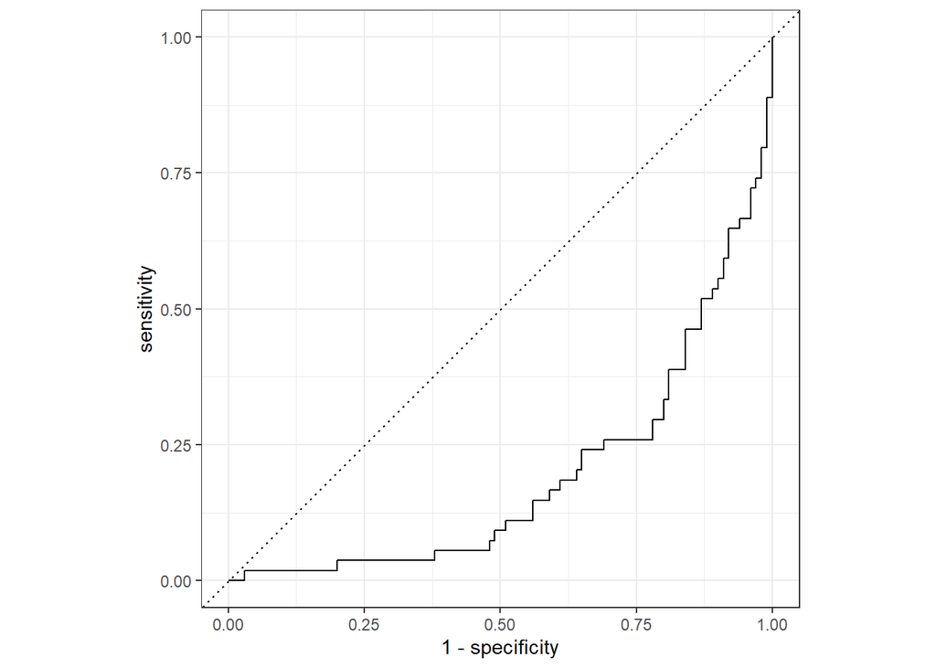

```r
autoplot(curva_roc)
```

# Segunda questão

2. Refaçam todos os exercícios dos slides; (valerá 2 pontos)

## Primeira parte da diciplina

1-Explique resumidamente o que é aprendizagem supervisionada e não-supervisionada. Cite um problema de aprendizagem supervisionada e um outro de aprendizagem não-supervisionada.

Supervisionada utiliza conjuntos de dados rotulados, sem a necessidade de uma pessoa externa para compreender o assunto.

Não supervisionada é quando não temos a resposta correta do conteudo, ou seja, temos a necessidade de pessoas externas para entendimento do assunto.

```r
setwd("E:/Downloads/Projeto")
load("E:/Downloads/Projeto/dados_expectativa_renda.RData")
set.seed(2023)
library(rsample)
library(dplyr)
library(ggplot2)
library(tidymodels)
library(tibble)
library(purrr)
library(patchwork)
library(glmnet)
tidymodels::tidymodels_prefer()
```

```r
dados <- dados_expectativa_renda[,-1]

dados_splitted <- initial_split(dados)

cross_validation <- vfold_cv(training(dados_splitted), v = 50)

eqm <- NULL

for(i in 1:50){
  data_temp <- cross_validation$splits[[i]] %>% analysis()
  fit_temp <- lm(data_temp$LifeExpectancy~., data_temp)

  Validatiion_temp <- cross_validation$splits[[i]] %>% assessment()

  eqm[i] <-  apply((Validatiion_temp[,1] - predict(fit_temp, Validatiion_temp))^2, MARGIN = 2, mean)

  if(i > 1){
    data_temp <- cross_validation$splits[[i]] %>% analysis()

    for(j in 2:i){
      assign(paste0("PIB per Capita",j), data_temp$GDPercapita^j)
      data_temp <- cbind(data_temp, get(paste0("PIB per Capita", j)))
    }
    colnames(data_temp) <- c("Expectativa de vida", "PIB per Capita", paste0("PIB per Capita", 2:i))

    fit_temp <- lm(data_temp$`Expectativa de vida`~. , data = data_temp)

    Validatiion_temp <- cross_validation$splits[[i]] %>% assessment()

    for(j in 2:i){
      assign(paste0("PIB per Capita", j), Validatiion_temp$GDPercapita^j)
      Validatiion_temp <- cbind(Validatiion_temp, get(paste0("PIB per Capita", j)))
    }
    colnames(Validatiion_temp) <- c("Expectativa de vida", "PIB per Capita", paste0("PIB per Capita", 2:i))

    eqm[i] <- mean((Validatiion_temp[,1] - predict(fit_temp, Validatiion_temp))^2)
  }
}
v=which(eqm == min(eqm))
print(v)
```

```
## [1] 25
```

3-Explique qual o motivo que faz com que o Erro Quadrático Médio - EQM para avaliar o desempenho de um modelo é ruim quando não adotamos nenhuma estratégia de divisão do conjunto de dados em treinamento e teste.

4-Com suas palavras, explique o dilema de balanço entre víes e variância.

5-Refaça o exercício do polinômio, utilizando a estratégia de data splitting, em que divide-se o conjunto de dados em treinamento e teste. Utilize o conjunto de teste para calcular a estimativa do risco, usando o EQM.

k-folds cross-validation utilizando data splitting com k =50

```r
dados <- dados_expectativa_renda[,-1]

dados_splitted <- initial_split(dados, prop = 3/4)
train_data <- training(dados_splitted)
test_data <- testing(dados_splitted)

cross_validation <- vfold_cv(train_data, v = 50)

eqm <- NULL

for(i in 1:50){
  data_temp <- cross_validation$splits[[i]] %>% analysis()
  fit_temp <- lm(data_temp$LifeExpectancy~., data_temp)

  Validatiion_temp <- cross_validation$splits[[i]] %>% assessment()

  eqm[i] <-  apply((Validatiion_temp[,1] - predict(fit_temp, Validatiion_temp))^2, MARGIN = 2, mean)

  if(i > 1){
    data_temp <- cross_validation$splits[[i]] %>% analysis()

    for(j in 2:i){
      assign(paste0("PIB per Capita",j), data_temp$GDPercapita^j)
      data_temp <- cbind(data_temp, get(paste0("PIB per Capita", j)))
    }
    colnames(data_temp) <- c("Expectativa de vida", "PIB per Capita", paste0("PIB per Capita", 2:i))

    fit_temp <- lm(data_temp$`Expectativa de vida`~. , data = data_temp)

    Validatiion_temp <- cross_validation$splits[[i]] %>% assessment()

    for(j in 2:i){
      assign(paste0("PIB per Capita", j), Validatiion_temp$GDPercapita^j)
      Validatiion_temp <- cbind(Validatiion_temp, get(paste0("PIB per Capita", j)))
    }
    colnames(Validatiion_temp) <- c("Expectativa de vida", "PIB per Capita", paste0("PIB per Capita", 2:i))

    eqm[i] <- mean((Validatiion_temp[,1] - predict(fit_temp, Validatiion_temp))^2)
  }
}

v=which(eqm == min(eqm))
print(v)
```

```
## [1] 35
```

6- Ainda considerando o exercício do polinômio, implemente uma estratégia de leave-one-out cross-validation e selecione o melhor modelo minimizando a função de risco.

Leave-one-out cross-validation;

```r
dados <- dados_expectativa_renda[,-1]

cross_validation <- loo_cv(dados)

eqm <- NULL

for(i in 1:50){
  data_temp <- cross_validation$splits[[i]] %>% analysis()
  fit_temp <- lm(data_temp$LifeExpectancy~., data_temp)

  Validatiion_temp <- cross_validation$splits[[i]] %>% assessment()

  eqm[i] <-  apply((Validatiion_temp[,1] - predict(fit_temp, Validatiion_temp))^2, MARGIN = 2, mean)

  if(i > 1){
    data_temp <- cross_validation$splits[[i]] %>% analysis()

    for(j in 2:i){
      assign(paste0("PIB per Capita",j), data_temp$GDPercapita^j)
      data_temp <- cbind(data_temp, get(paste0("PIB per Capita", j)))
    }
    colnames(data_temp) <- c("Expectativa de vida", "PIB per Capita", paste0("PIB per Capita", 2:i))

    fit_temp <- lm(data_temp$`Expectativa de vida`~. , data = data_temp)

    Validatiion_temp <- cross_validation$splits[[i]] %>% assessment()

    for(j in 2:i){
      assign(paste0("PIB per Capita", j), Validatiion_temp$GDPercapita^j)
      Validatiion_temp <- cbind(Validatiion_temp, get(paste0("PIB per Capita", j)))
    }
    colnames(Validatiion_temp) <- c("Expectativa de vida", "PIB per Capita", paste0("PIB per Capita", 2:i))

    eqm[i] <- mean((Validatiion_temp[,1] - predict(fit_temp, Validatiion_temp))^2)
  }
}

v=which(eqm == min(eqm))
print(v)
```

```
## [1] 34
```

7- Por fim, considerando o exercício do polinômio, rafaça-o utilizando um procedimento de kk-fold cross-validation. Considere k = 5k=5. Dica: considere utiliza a biblioteca rsample.

k-folds cross-validation utilizando data splitting com k = 5

```r
dados <- dados_expectativa_renda[,-1]

dados_splitted <- initial_split(dados, prop = 3/4)
train_data <- training(dados_splitted)
test_data <- testing(dados_splitted)

cross_validation <- vfold_cv(train_data, v = 5)

eqm <- NULL

for(i in 1:5){
  data_temp <- cross_validation$splits[[i]] %>% analysis()
  fit_temp <- lm(data_temp$LifeExpectancy~., data_temp)

  Validatiion_temp <- cross_validation$splits[[i]] %>% assessment()

  eqm[i] <-  apply((Validatiion_temp[,1] - predict(fit_temp, Validatiion_temp))^2, MARGIN = 2, mean)

  if(i > 1){
    data_temp <- cross_validation$splits[[i]] %>% analysis()

    for(j in 2:i){
      assign(paste0("PIB per Capita",j), data_temp$GDPercapita^j)
      data_temp <- cbind(data_temp, get(paste0("PIB per Capita", j)))
    }
    colnames(data_temp) <- c("Expectativa de vida", "PIB per Capita", paste0("PIB per Capita", 2:i))

    fit_temp <- lm(data_temp$`Expectativa de vida`~. , data = data_temp)

    Validatiion_temp <- cross_validation$splits[[i]] %>% assessment()

    for(j in 2:i){
      assign(paste0("PIB per Capita", j), Validatiion_temp$GDPercapita^j)
      Validatiion_temp <- cbind(Validatiion_temp, get(paste0("PIB per Capita", j)))
    }
    colnames(Validatiion_temp) <- c("Expectativa de vida", "PIB per Capita", paste0("PIB per Capita", 2:i))

    eqm[i] <- mean((Validatiion_temp[,1] - predict(fit_temp, Validatiion_temp))^2)
  }
}

v=which(eqm == min(eqm))
print(v)
```

```
## [1] 5
```

- Vinhos

```r
vinhos <- read.csv("E:/Downloads/Projeto/winequality-red.csv")
skimr::skim(vinhos)
```

Data summary

| Name | vinhos |
| --- | --- |
| Number of rows | 1599 |
| Number of columns | 12 |
| _______________________ |  |
| Column type frequency: |  |
| numeric | 12 |
| ________________________ |  |
| Group variables | None |

**Variable type: numeric**

| skim_variable | n_missing | complete_rate | mean | sd | p0 | p25 | p50 | p75 | p100 | hist |
| --- | --- | --- | --- | --- | --- | --- | --- | --- | --- | --- |
| fixed.acidity | 0 | 1 | 8.32 | 1.74 | 4.60 | 7.10 | 7.90 | 9.20 | 15.90 | ▂▇▂▁▁ |
| volatile.acidity | 0 | 1 | 0.53 | 0.18 | 0.12 | 0.39 | 0.52 | 0.64 | 1.58 | ▅▇▂▁▁ |
| citric.acid | 0 | 1 | 0.27 | 0.19 | 0.00 | 0.09 | 0.26 | 0.42 | 1.00 | ▇▆▅▁▁ |
| residual.sugar | 0 | 1 | 2.54 | 1.41 | 0.90 | 1.90 | 2.20 | 2.60 | 15.50 | ▇▁▁▁▁ |
| chlorides | 0 | 1 | 0.09 | 0.05 | 0.01 | 0.07 | 0.08 | 0.09 | 0.61 | ▇▁▁▁▁ |
| free.sulfur.dioxide | 0 | 1 | 15.87 | 10.46 | 1.00 | 7.00 | 14.00 | 21.00 | 72.00 | ▇▅▁▁▁ |
| total.sulfur.dioxide | 0 | 1 | 46.47 | 32.90 | 6.00 | 22.00 | 38.00 | 62.00 | 289.00 | ▇▂▁▁▁ |
| density | 0 | 1 | 1.00 | 0.00 | 0.99 | 1.00 | 1.00 | 1.00 | 1.00 | ▁▃▇▂▁ |
| pH | 0 | 1 | 3.31 | 0.15 | 2.74 | 3.21 | 3.31 | 3.40 | 4.01 | ▁▅▇▂▁ |
| sulphates | 0 | 1 | 0.66 | 0.17 | 0.33 | 0.55 | 0.62 | 0.73 | 2.00 | ▇▅▁▁▁ |
| alcohol | 0 | 1 | 10.42 | 1.07 | 8.40 | 9.50 | 10.20 | 11.10 | 14.90 | ▇▇▃▁▁ |
| quality | 0 | 1 | 5.64 | 0.81 | 3.00 | 5.00 | 6.00 | 6.00 | 8.00 | ▁▇▇▂▁ |

```r
colnames(vinhos) <- c(paste0("x", 1:11), "y")
#Data split
vinho <- initial_split(vinhos, prop = 3/4)

trainer <- training(vinho)
tester <- testing(vinho)

#Setting Engine
modelo_mmo <-
  linear_reg(penalty = 0, mixture = 0) %>%
  set_mode("regression") %>%
  set_engine("glmnet")

modelo_ridge <-
  linear_reg(penalty = tune::tune(), mixture = 0) %>%
  set_mode("regression") %>%
  set_engine("glmnet")

modelo_lasso <-
  parsnip::linear_reg(penalty = tune::tune(), mixture = 1) %>%
  set_mode("regression") %>%
  parsnip::set_engine("glmnet")

modelo_elastic <-
  parsnip::linear_reg(penalty = tune::tune(), mixture = tune::tune()) %>%
  set_mode("regression") %>%
  parsnip::set_engine("glmnet")


#workflow
all_wf <-
  workflow_set(
    preproc = list(y ~ . ),
    models = list(mmo = modelo_mmo, ridge = modelo_ridge, lasso = modelo_lasso, elastic = modelo_elastic),
    cross = TRUE
  )

#cross-validation
set.seed(2023)
cv <- rsample::vfold_cv(trainer, v = 5L)

#metrics
metrica <- yardstick::metric_set(rmse)

#tunning
tunagem <-
  all_wf %>%
  workflow_map(
    seed = 2023,
    verbose = TRUE,
    resamples = cv,
    grid = 50,
    metrics = metrica
  )
```

```
## i    No tuning parameters. `fit_resamples()` will be attempted
```

```
## i 1 of 4 resampling: formula_mmo
```

```
## ✔ 1 of 4 resampling: formula_mmo (270ms)
```

```
## i 2 of 4 tuning:     formula_ridge
```

```
## ✔ 2 of 4 tuning:     formula_ridge (730ms)
```

```
## i 3 of 4 tuning:     formula_lasso
```

```
## ✔ 3 of 4 tuning:     formula_lasso (750ms)
```

```
## i 4 of 4 tuning:     formula_elastic
```

```
## ✔ 4 of 4 tuning:     formula_elastic (14.6s)
```

```r
#melhores modelos
modelos_rank <- tunagem %>% rank_results()

melhor_mmo <-
  tunagem %>%
  extract_workflow_set_result("formula_mmo") %>%
  select_best("rmse")

melhor_ridge <-
  tunagem %>%
  extract_workflow_set_result("formula_ridge") %>%
  select_best("rmse")

melhor_lasso <-
  tunagem %>%
  extract_workflow_set_result("formula_lasso") %>%
  select_best("rmse")

melhor_elastic <-
  tunagem %>%
  extract_workflow_set_result("formula_elastic") %>%
  select_best("rmse")

finalizando_mmo <-
  tunagem %>%
  extract_workflow("formula_mmo") %>%
  finalize_workflow(melhor_mmo) %>%
  last_fit(split = vinho)

finalizando_ridge <-
  tunagem %>%
  extract_workflow("formula_ridge") %>%
  finalize_workflow(melhor_ridge) %>%
  last_fit(split = vinho)

finalizando_lasso <-
  tunagem %>%
  extract_workflow("formula_lasso") %>%
  finalize_workflow(melhor_lasso) %>%
  last_fit(split = vinho)

finalizando_elastic <-
  tunagem %>%
  extract_workflow("formula_elastic") %>%
  finalize_workflow(melhor_elastic) %>%
  last_fit(split = vinho)
```

```r
library(knitr)
kable(data.frame(row.names = c("MMO", "Ridge", "Lasso", "Elastic"),
                        "RMSE" = as.numeric(c((finalizando_mmo  %>%  collect_metrics())[1,3],
                                              (finalizando_ridge %>% collect_metrics())[1,3],
                                              (finalizando_lasso %>% collect_metrics())[1,3],
                                              (finalizando_elastic %>% collect_metrics())[1,3])))


)
```

|  | RMSE |
| --- | --- |
| MMO | 0.6602223 |
| Ridge | 0.6602223 |
| Lasso | 0.6618038 |
| Elastic | 0.6616312 |

```r
features <- trainer[,-12] %>% as.matrix()
ytrainer <- trainer[,12] %>% as.matrix()
testfeatures <- tester[,-12] %>% as.matrix()
ytest <- tester[,12] %>% as.matrix()

#MMO

fit <- glmnet(x = features, y = ytrainer, alpha = 0, lambda = 0)
preditos <- predict(fit, newx = testfeatures)
eqm_mmo <- mean((preditos - ytest)^2)


#Ridge
cvridge <- cv.glmnet(x = features, y = ytrainer, alpha = 0, nfolds = 5)
fit2 <- glmnet(x = features, y = ytrainer, alpha = 0)
preditos_ridge <- predict(fit2, s = cvridge$lambda.1se, newx = testfeatures)
eqm_ridge <- mean((preditos_ridge - ytest)^2)

#Lasso
cvlasso <- cv.glmnet(x = features, y = ytrainer, alpha = 1, nfolds = 5)
fit3 <- glmnet(x = features, y = ytrainer, alpha = 1)
preditos_lasso <- predict(fit3, s = cvlasso$lambda.1se, newx = testfeatures)
eqm_lass <- mean((preditos_lasso - ytest)^2)

#Elastic-net
#Precisamos estipular o melhor alpha através de uma validaçao cruzada.
#Utilizando 5-folds.
eqm_elastic <- NULL
alpha_values <- seq(0.01, 0.999, length.out = 500)
for(a in alpha_values){
  cvelastic <- cv.glmnet(x = features, y = ytrainer, alpha = a, nfolds = 5)
  tempfit <- glmnet(x = features, y = ytrainer, alpha = a)
  preditos_elastic <- predict(tempfit, s = cvelastic$lambda.1se, newx = testfeatures)
  eqm_elastic <- c(eqm_elastic,
                   mean((preditos_elastic - ytest)^2))
}
print(min(eqm_elastic))
```

```
## [1] 0.4390524
```

```r
kable(data.frame(row.names = c("MMO", "Ridge", "Lasso", "Elastic"),
                        "EQM" = c(eqm_mmo, eqm_ridge, eqm_lass, min(eqm_elastic)),
                        "RMSE" = sqrt(c(eqm_mmo, eqm_ridge, eqm_lass, min(eqm_elastic)))
                        )
)
```

|  | EQM | RMSE |
| --- | --- | --- |
| MMO | 0.4374730 | 0.6614174 |
| Ridge | 0.4404013 | 0.6636274 |
| Lasso | 0.4471173 | 0.6686683 |
| Elastic | 0.4390524 | 0.6626103 |

- despesas médicas

```r
despesas <- read.csv("insurance.csv")

dados_t <- recipe(charges ~., data = despesas) %>%
  step_dummy(all_nominal(), -all_outcomes()) %>%
  prep() %>% juice()

knitr::kable(dados_t %>% head(10), format = "html")
```

| age | bmi | children | charges | sex_male | smoker_yes | region_northwest | region_southeast | region_southwest |
| --- | --- | --- | --- | --- | --- | --- | --- | --- |
| 19 | 27.900 | 0 | 16884.924 | 0 | 1 | 0 | 0 | 1 |
| 18 | 33.770 | 1 | 1725.552 | 1 | 0 | 0 | 1 | 0 |
| 28 | 33.000 | 3 | 4449.462 | 1 | 0 | 0 | 1 | 0 |
| 33 | 22.705 | 0 | 21984.471 | 1 | 0 | 1 | 0 | 0 |
| 32 | 28.880 | 0 | 3866.855 | 1 | 0 | 1 | 0 | 0 |
| 31 | 25.740 | 0 | 3756.622 | 0 | 0 | 0 | 1 | 0 |
| 46 | 33.440 | 1 | 8240.590 | 0 | 0 | 0 | 1 | 0 |
| 37 | 27.740 | 3 | 7281.506 | 0 | 0 | 1 | 0 | 0 |
| 37 | 29.830 | 2 | 6406.411 | 1 | 0 | 0 | 0 | 0 |
| 60 | 25.840 | 0 | 28923.137 | 0 | 0 | 1 | 0 | 0 |

```r
df <- initial_split(dados_t, prop = 3/4)

trainer <- training(df)
tester <- testing(df)

#Setting Engine
modelo_mmo <-
  linear_reg(penalty = 0, mixture = 0) %>%
  set_mode("regression") %>%
  set_engine("glmnet")

modelo_ridge <-
  linear_reg(penalty = tune::tune(), mixture = 0) %>%
  set_mode("regression") %>%
  set_engine("glmnet")

modelo_lasso <-
  parsnip::linear_reg(penalty = tune::tune(), mixture = 1) %>%
  set_mode("regression") %>%
  parsnip::set_engine("glmnet")

modelo_elastic <-
  parsnip::linear_reg(penalty = tune::tune(), mixture = tune::tune()) %>%
  set_mode("regression") %>%
  parsnip::set_engine("glmnet")


#workflow
all_wf <-
  workflow_set(
    preproc = list(charges ~ . ),
    models = list(mmo = modelo_mmo, ridge = modelo_ridge, lasso = modelo_lasso, elastic = modelo_elastic),
    cross = TRUE
  )

#cross-validation
set.seed(2023)
cv <- rsample::vfold_cv(trainer, v = 5L)

#metrics
metrica <- yardstick::metric_set(rmse)

#tunning
tunagem <-
  all_wf %>%
  workflow_map(
    seed = 2023,
    verbose = TRUE,
    resamples = cv,
    grid = 50,
    metrics = metrica
  )
```

```
## i    No tuning parameters. `fit_resamples()` will be attempted
```

```
## i 1 of 4 resampling: formula_mmo
```

```
## ✔ 1 of 4 resampling: formula_mmo (220ms)
```

```
## i 2 of 4 tuning:     formula_ridge
```

```
## ✔ 2 of 4 tuning:     formula_ridge (720ms)
```

```
## i 3 of 4 tuning:     formula_lasso
```

```
## ✔ 3 of 4 tuning:     formula_lasso (701ms)
```

```
## i 4 of 4 tuning:     formula_elastic
```

```
## ✔ 4 of 4 tuning:     formula_elastic (14.8s)
```

```r
modelos_rank <- tunagem %>% rank_results()

melhor_mmo <-
  tunagem %>%
  extract_workflow_set_result("formula_mmo") %>%
  select_best("rmse")

melhor_ridge <-
  tunagem %>%
  extract_workflow_set_result("formula_ridge") %>%
  select_best("rmse")

melhor_lasso <-
  tunagem %>%
  extract_workflow_set_result("formula_lasso") %>%
  select_best("rmse")

melhor_elastic <-
  tunagem %>%
  extract_workflow_set_result("formula_elastic") %>%
  select_best("rmse")

finalizando_mmo <-
  tunagem %>%
  extract_workflow("formula_mmo") %>%
  finalize_workflow(melhor_mmo) %>%
  last_fit(split = df)

finalizando_ridge <-
  tunagem %>%
  extract_workflow("formula_ridge") %>%
  finalize_workflow(melhor_ridge) %>%
  last_fit(split = df)

finalizando_lasso <-
  tunagem %>%
  extract_workflow("formula_lasso") %>%
  finalize_workflow(melhor_lasso) %>%
  last_fit(split = df)

finalizando_elastic <-
  tunagem %>%
  extract_workflow("formula_elastic") %>%
  finalize_workflow(melhor_elastic) %>%
  last_fit(split = df)


knitr::kable(data.frame(row.names = c("MMO", "Ridge", "Lasso", "Elastic"),
                        "RMSE" = as.numeric(c((finalizando_mmo  %>%  collect_metrics())[1,3],
                                              (finalizando_ridge %>% collect_metrics())[1,3],
                                              (finalizando_lasso %>% collect_metrics())[1,3],
                                              (finalizando_elastic %>% collect_metrics())[1,3])))
)
```

|  | RMSE |
| --- | --- |
| MMO | 5511.307 |
| Ridge | 5511.307 |
| Lasso | 5509.272 |
| Elastic | 5508.648 |

seleção de modelos

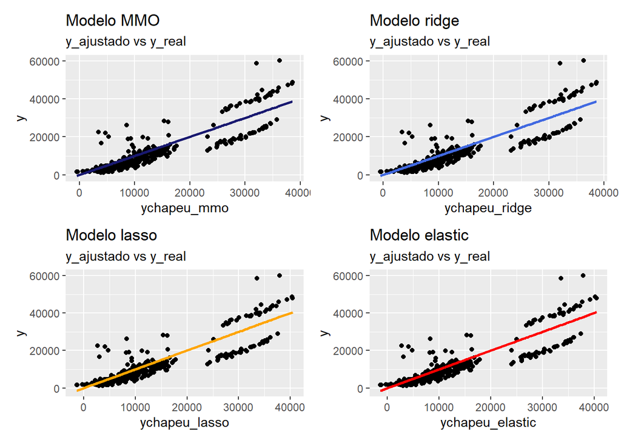

```r
data_temp <- data.frame(ychapeu_mmo = (finalizando_mmo %>% collect_predictions())[2],
                        ychapeu_ridge = (finalizando_ridge %>% collect_predictions())[2],
                        ychapeu_lasso = (finalizando_lasso %>% collect_predictions())[2],
                        ychapeu_elastic = (finalizando_elastic %>% collect_predictions())[2],
                        y = (finalizando_elastic %>% collect_predictions())[4]
)

colnames(data_temp) <- c("ychapeu_mmo", "ychapeu_ridge", "ychapeu_lasso", "ychapeu_elastic", "y")
data_temp <- as_tibble(data_temp)


g1 <- ggplot(data_temp, aes(x = ychapeu_mmo, y = y)) +
  geom_point() + geom_line(aes(y = ychapeu_mmo), colour = "#191970", size = 1) +
  labs(title = "Modelo MMO", subtitle = "y_ajustado vs y_real")
g2 <- ggplot(data_temp, aes(x = ychapeu_ridge, y = y)) +
  geom_point() + geom_line(aes(y = ychapeu_ridge), colour = "#4169E1", size = 1) +
  labs(title = "Modelo ridge", subtitle = "y_ajustado vs y_real")

g3 <- ggplot(data_temp, aes(x = ychapeu_lasso, y = y)) +
  geom_point() + geom_line(aes(y = ychapeu_lasso), colour = "orange", size = 1) +
  labs(title = "Modelo lasso", subtitle = "y_ajustado vs y_real")

g4 <- ggplot(data_temp, aes(x = ychapeu_elastic, y = y)) +
  geom_point() + geom_line(aes(y = ychapeu_elastic), colour = "red", size = 1) +
  labs(title = "Modelo elastic", subtitle = "y_ajustado vs y_real")


(g1 + g2) / (g3 + g4)
```

```r
set.seed(23)
# Carrega todas as bibliotecas necessárias
pacotes <- c("tidymodels", "rpart", "rpart.plot", "glue", "dplyr", "ggplot2", "patchwork","parsnip")

# Instala os pacotes que não estão instalados
pacotes_nao_instalados <- pacotes[!(pacotes %in% installed.packages()[,"Package"])]
if(length(pacotes_nao_instalados) > 0) {
  install.packages(pacotes_nao_instalados)
}

# Carrega as bibliotecas
lapply(pacotes, library, character.only = TRUE)
```

[output not shown]

[output cut: 56 more lines]

```r
tidymodels::tidymodels_prefer()
```

### Primeiro exercicios(slide 161):

```r
performace_alunos <- read.csv("E:/Downloads/Projeto/Student_Performance.csv")
nomes_em_portugues <- c("Horas_Estudadas", "Notas_Anteriores", "Atividades_Extracurriculares",
                        "Horas_de_Sono", "Exercicios_de_Amostra_Praticados", "Indice_de_Desempenho")
colnames(performace_alunos) <- nomes_em_portugues
names(performace_alunos)
```

```
## [1] "Horas_Estudadas"                  "Notas_Anteriores"
## [3] "Atividades_Extracurriculares"     "Horas_de_Sono"
## [5] "Exercicios_de_Amostra_Praticados" "Indice_de_Desempenho"
```

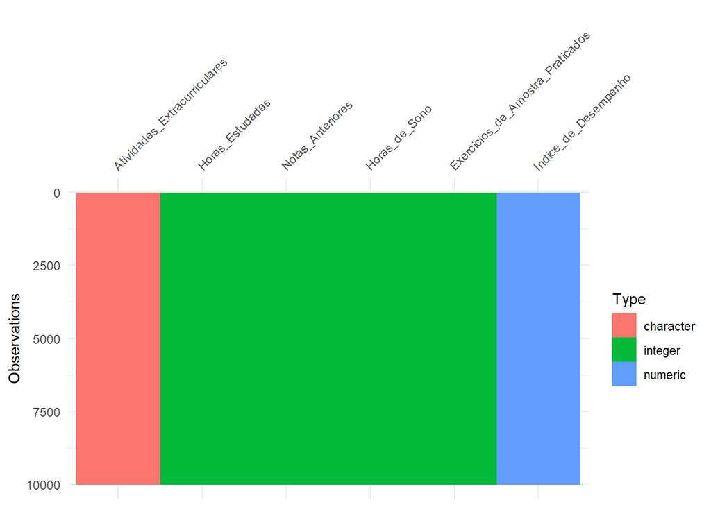

```r
visdat::vis_dat(performace_alunos)
```

Não temos NA na nossa base, vamos forçar alguns NA para atividade

```r
criar_na_aleatoriamente <- function(dados, proporcao_na = 0.10) {
  dados1 <- dados

  num_colunas <- sample(1:ncol(dados1), 1)

  num_obs_com_na <- floor(proporcao_na * nrow(dados1))

  colunas_com_na <- sample(1:ncol(dados1), num_colunas)

  indices_com_na <- sample(1:nrow(dados1), num_obs_com_na)

  for (coluna in colunas_com_na) {
    dados1[indices_com_na, coluna] <- NA
  }

  return(dados1)
}

dados1 <- criar_na_aleatoriamente(performace_alunos)
```

aplicamos 10% de Na aleatoriamente.

```r
dados1 |>
  dplyr::glimpse()
```

```
## Rows: 10,000
## Columns: 6
## $ Horas_Estudadas                  <int> 7, 4, 8, NA, 7, 3, 7, 8, 5, 4, 8, 8, …
## $ Notas_Anteriores                 <int> 99, 82, 51, 52, 75, 78, 73, 45, 77, 8…
## $ Atividades_Extracurriculares     <chr> "Yes", "No", "Yes", NA, "No", "No", "…
## $ Horas_de_Sono                    <int> 9, 4, 7, NA, 8, 9, 5, 4, 8, 4, 4, 6, …
## $ Exercicios_de_Amostra_Praticados <int> 1, 2, 2, NA, 5, 6, 6, 6, 2, 0, 5, 2, …
## $ Indice_de_Desempenho             <dbl> 91, 65, 45, NA, 66, 61, 63, 42, 61, 6…
```

#### Iniciando receita

```r
student_split  <- initial_split(dados1, prop = 0.9, strata = Indice_de_Desempenho )
treinamento <- training(student_split)
teste <- testing(student_split)
```

```r
receita <- recipe(formula = Indice_de_Desempenho ~ ., data = dados1) %>%
  step_impute_knn(all_predictors(),
                  impute_with =  c("Notas_Anteriores", "Horas_de_Sono","Indice_de_Desempenho"),
                  neighbors = 15L) %>%
  step_dummy(Atividades_Extracurriculares) %>%
  step_YeoJohnson(all_numeric_predictors()) %>%
  step_normalize(all_numeric_predictors())
```

Imputamos dados faltantes usando KNN para variáveis numéricas. Em seguida, transformamos uma variável categórica em dummy. Aplicamos Yeo-Johnson para aproximar os dados de uma distribuição normal e, por fim, normalizamos todas as variáveis para análises mais detalhadas.

#### Construido os modelos

```r
elastic <-
  linear_reg(penalty = tune(),
             mixture = tune()) %>%
  set_mode("regression") %>%
  set_engine("glmnet")

knn <-
  nearest_neighbor(
    neighbors = tune()
  ) %>%
  set_mode("regression") %>%
  set_engine("kknn")

svm <-
  svm_rbf(
    cost = tune(),
    rbf_sigma = tune(),
    margin = tune()
  ) %>%
  set_mode("regression") %>%
  set_engine("kernlab")

all_wf <-
   workflow_set(
     preproc = list(receita),
     models = list(
       modelo_knn = knn,
       modelo_svm = svm,
       modelo_elastic = elastic
     ),
     cross = TRUE
   ) %>%
  mutate(wflow_id = gsub("(recipe_)", "", wflow_id))

grid_control <- control_grid(
  save_pred = TRUE,
  save_workflow = TRUE,
  parallel_over = "resamples"
)

vfold <-
  treinamento %>%
  vfold_cv(v = 15L, strata = Indice_de_Desempenho)

metrica <- metric_set(rmse)
```

```r
grid_knn <- grid_max_entropy(all_wf %>% extract_parameter_set_dials("modelo_knn"), size = 50L)
grid_elastic <- grid_max_entropy(all_wf %>% extract_parameter_set_dials("modelo_elastic"), size = 100L)
grid_svm <-  grid_max_entropy(all_wf %>% extract_parameter_set_dials("modelo_svm"), size = 30L)
```

```r
all_wf <-
  all_wf %>%
  option_add(grid = grid_knn, id = 'modelo_knn') %>%
  option_add(grid = grid_elastic, id = 'modelo_elastic') %>%
  option_add(grid = grid_svm, id = 'modelo_svm')
```

#### Finalização

```r
tunagem <-
  all_wf %>%
  workflow_map(
    verbose = TRUE,
    resamples = vfold,
    control = grid_control,
    metrics = metrica
  )
```

```
## i 1 of 3 tuning:     modelo_knn
```

```
## ✔ 1 of 3 tuning:     modelo_knn (1m 13.1s)
```

```
## i 2 of 3 tuning:     modelo_svm
```

```
## ✔ 2 of 3 tuning:     modelo_svm (1h 29m 2.7s)
```

```
## i 3 of 3 tuning:     modelo_elastic
```

[output not shown]

[output not shown]

[output cut: 1117 more lines]

[output not shown]

[output not shown]

```r
best = tunagem %>%
  extract_workflow_set_result("modelo_svm") %>%
  select_best(metric = "rmse")

best %>%
  knitr::kable(caption = "Hiperparametros")
```

Hiperparametros

| cost | rbf_sigma | margin | .config |
| --- | --- | --- | --- |
| 6.951339 | 0.0242357 | 0.0909739 | Preprocessor1_Model02 |

```r
wf_final <-
  tunagem %>% extract_workflow("modelo_svm") %>%
  finalize_workflow(best)

teste <-
  wf_final %>%
  last_fit(split = student_split)

knitr::kable(teste$.metrics, caption = "Resultados")
```

Resultados

| .metric | .estimator | .estimate | .config |
| --- | --- | --- | --- |
| rmse | standard | 2.0136100 | Preprocessor1_Model1 |
| rsq | standard | 0.9893633 | Preprocessor1_Model1 |

#### modell final

```r
modelo_final <-
  wf_final |>
  fit(dados1)
```

### Atividade 2 (slide 190)

#### Lendo o banco e tratando os dados

```r
insurance <- read.csv("E:/Downloads/Projeto/insurance.csv")
colnames(insurance) <- c("Idade", "Sexo", "IMC", "Numero_de_Filhos", "Fumante", "Regiao", "Custos_de_Seguro")
```

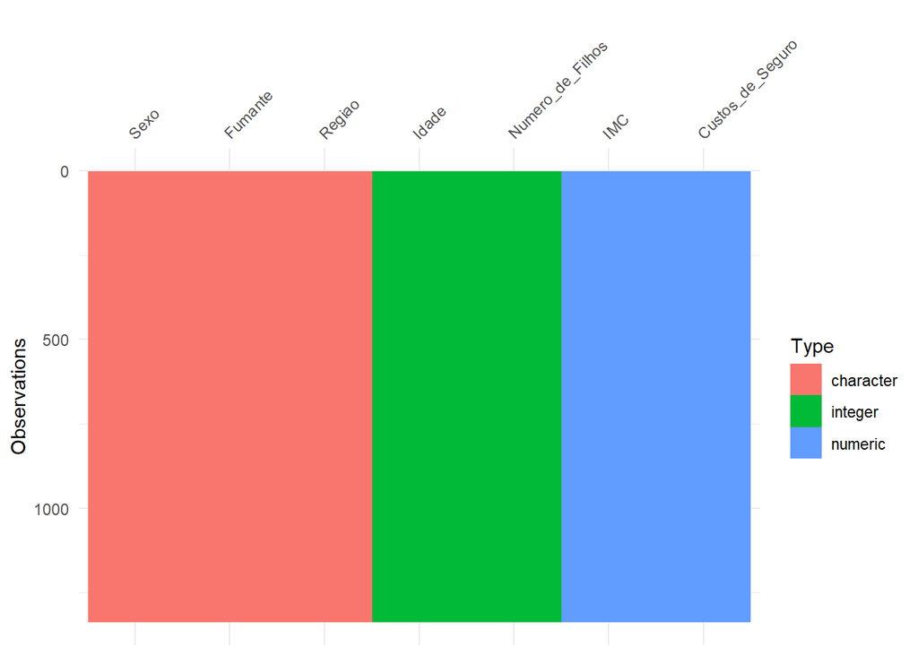

```r
visdat::vis_dat(insurance)
```

Não temos NA’s na base, 3 categoricas

#### Receita e modelos

```r
insurance_splitted <- initial_split(insurance, prop = 0.9, strata = Custos_de_Seguro)
treinamento <- training(insurance_splitted)
teste <- testing(insurance_splitted)
```

```r
receita <- recipe(formula = Custos_de_Seguro ~ . , insurance) %>%
  step_dummy(c(Sexo, Fumante,Regiao), one_hot = TRUE) %>%
  step_YeoJohnson(all_numeric_predictors()) %>%
  step_normalize(all_numeric_predictors())
```

A questão pede para transformar região em numérica, entretanto acho que as outras também são interessantes

```r
elastic <-
  linear_reg(penalty = tune(),
             mixture = tune()
  ) %>%
  set_mode("regression") %>%
  set_engine("glmnet")

knn <-
  nearest_neighbor(
    neighbors = tune()
  ) %>%
  set_mode("regression") %>%
  set_engine("kknn")

svm <-
  svm_rbf(
    cost = tune(),
    rbf_sigma = tune(),
    margin = tune()
  ) %>%
  set_mode("regression") %>%
  set_engine("kernlab")

all_wf <-
   workflow_set(
     preproc = list(receita),
     models = list(
       modelo_knn = knn,
       modelo_svm = svm,
       modelo_elastic = elastic
     ),
     cross = TRUE
   ) %>%
  mutate(wflow_id = gsub("(recipe_)", "", wflow_id))

grid_control <- control_grid(
  save_pred = TRUE,
  save_workflow = TRUE,
  parallel_over = "resamples"
)

vfold <-
  treinamento %>%
  vfold_cv(v = 15, strata = Custos_de_Seguro)

metrica <- metric_set(rmse)
```

```r
grid_knn <- grid_max_entropy(all_wf %>% extract_parameter_set_dials("modelo_knn"), size = 50L)
grid_elastic <- grid_max_entropy(all_wf %>% extract_parameter_set_dials("modelo_elastic"), size = 100L)
grid_svm <-  grid_max_entropy(all_wf %>% extract_parameter_set_dials("modelo_svm"), size = 30L)
```

```r
all_wf <-
  all_wf %>%
  option_add(grid = grid_knn, id = 'modelo_knn') %>%
  option_add(grid = grid_elastic, id = 'modelo_elastic') %>%
  option_add(grid = grid_svm, id = 'modelo_svm')
```

#### melhor modelo

```r
tunagem <-
  all_wf %>%
  workflow_map(
    verbose = TRUE,
    seed = 23,
    resamples = vfold,
    control = grid_control,
    metrics = metrica
  )
```

```
## i 1 of 3 tuning:     modelo_knn
```

```
## ✔ 1 of 3 tuning:     modelo_knn (6.5s)
```

```
## i 2 of 3 tuning:     modelo_svm
```

```
## ✔ 2 of 3 tuning:     modelo_svm (2m 23.9s)
```

```
## i 3 of 3 tuning:     modelo_elastic
```

```
## ✔ 3 of 3 tuning:     modelo_elastic (1m 39.5s)
```

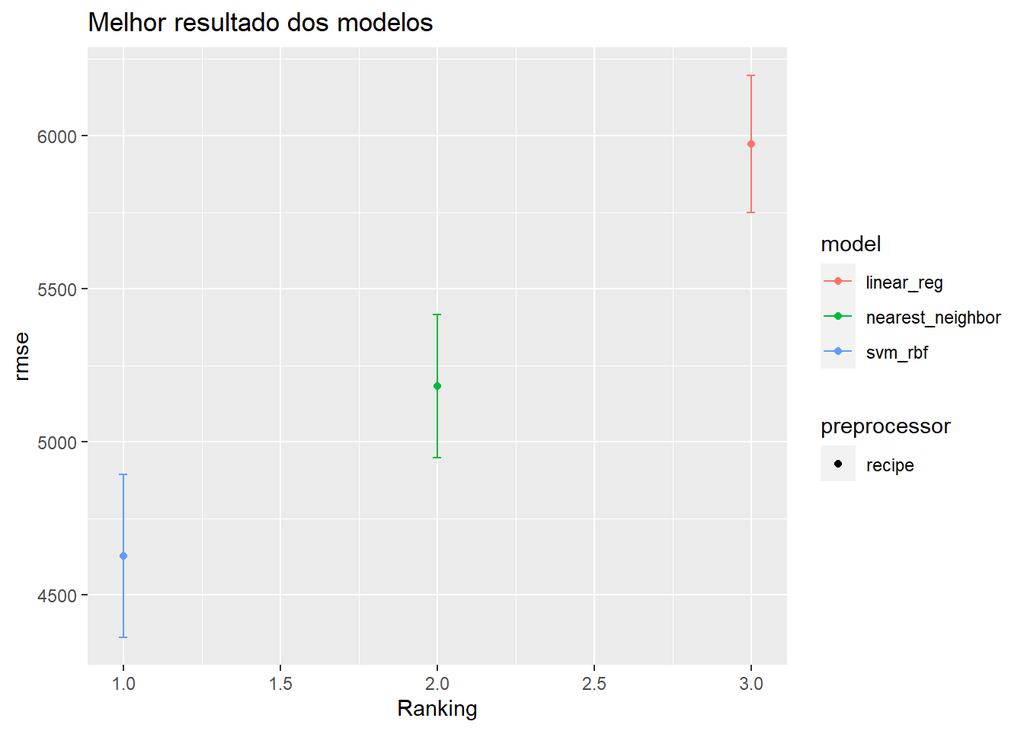

```r
autoplot(
  tunagem,
  rank_metric = "rmse",
  metric = "rmse",
  select_best = TRUE
) +
  labs(title = "Melhor resultado dos modelos")+ ylab("rmse")+ xlab("Ranking")
```

SVM é o modelo com menor erro

```r
best = tunagem %>%
  extract_workflow_set_result("modelo_svm") %>%
  select_best(metric = "rmse")

best %>%
  knitr::kable(caption = "Hiperparametros")
```

Hiperparametros

| cost | rbf_sigma | margin | .config |
| --- | --- | --- | --- |
| 16.28545 | 0.009177 | 0.1050711 | Preprocessor1_Model24 |

```r
wf_final <-
  tunagem %>% extract_workflow("modelo_svm") %>%
  finalize_workflow(best)

teste <-
  wf_final %>%
  last_fit(split = insurance_splitted)

knitr::kable(teste$.metrics, caption = "Resultados")
```

Resultados

| .metric | .estimator | .estimate | .config |
| --- | --- | --- | --- |
| rmse | standard | 5921.413271 | Preprocessor1_Model1 |
| rsq | standard | 0.751407 | Preprocessor1_Model1 |

```r
modelo_final <-
  wf_final |>
  fit(insurance)
```

```r
modelo_final
```

```
## ══ Workflow [trained] ══════════════════════════════════════════════════════════
## Preprocessor: Recipe
## Model: svm_rbf()
##
## ── Preprocessor ────────────────────────────────────────────────────────────────
## 3 Recipe Steps
##
## • step_dummy()
## • step_YeoJohnson()
## • step_normalize()
##
## ── Model ───────────────────────────────────────────────────────────────────────
## Support Vector Machine object of class "ksvm"
##
## SV type: eps-svr  (regression)
##  parameter : epsilon = 0.105071127414703  cost C = 16.2854512766984
##
## Gaussian Radial Basis kernel function.
##  Hyperparameter : sigma =  0.00917702858219558
##
## Number of Support Vectors : 450
##
## Objective Function Value : -2836.921
## Training error : 0.15198
```

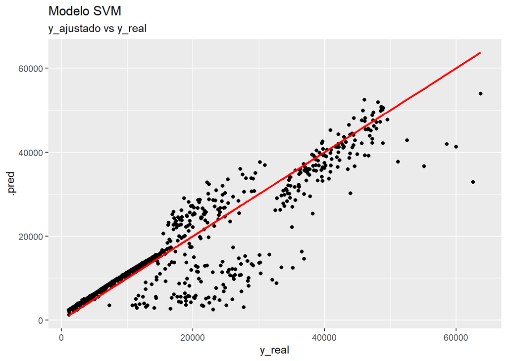

```r
y_predito <- predict(modelo_final, new_data = insurance)

dados_predicao <- data.frame(y_real = insurance$Custos_de_Seguro, y_predito = y_predito)

ggplot(dados_predicao, aes(x = y_real, y = .pred)) +
  geom_point() +
  geom_line(aes(y = y_real), color = "red", size = 1) +
  labs(title = "Modelo SVM", subtitle = "y_ajustado vs y_real")
```

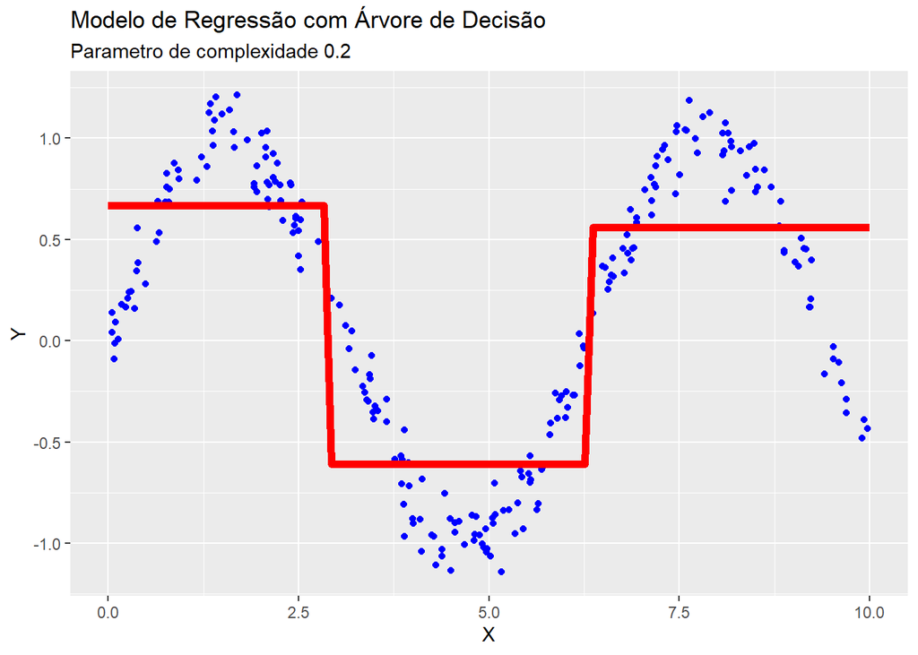

```r
arvore <- function(n , complexidade, sigma) {

  X <- runif(n, 0, 10)
  Y <- sin(X) + rnorm(n, 0, sigma)

  modelo <- rpart(Y ~ X, control = rpart.control(cp = complexidade))

  X_seno <- seq(0, 10, length.out = 100)
  Y_predito <- predict(modelo, newdata = data.frame(X = X_seno))

dados <- data.frame(X = X, Y = Y)
  ggplot() +
    geom_point(data = dados, aes(x = X, y = Y), color = "blue", shape = 19) +
    geom_line(data = data.frame(X = X_seno, Y = Y_predito), aes(x = X, y = Y), color = "red", size = 2) +
    labs(x = "X", y = "Y", title = "Modelo de Regressão com Árvore de Decisão",
         subtitle = "Parametro de complexidade 0.2")

}

arvore(n=250,complexidade = 0.2,sigma = 0.1)
```

### exercicio

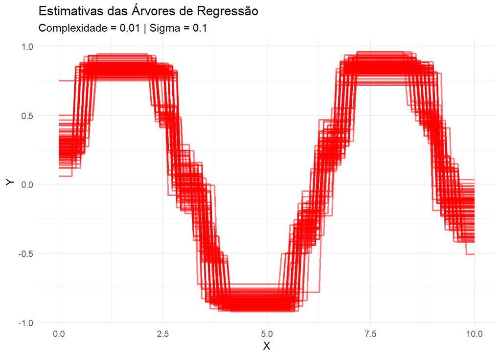

```r
arvores_estimativas <- function(n = 250L, complexidade = 0.01, sigma = 0.1, num_arvores ) {
  resultados <- list()

  for (i in 1:num_arvores) {
    X <- runif(n, 0, 10)
    Y <- sin(X) + rnorm(n, 0, sigma)

    modelo <- rpart(Y ~ X, control = rpart.control(cp = complexidade))

    X_seno <- seq(0, 10, length.out = 100)
    Y_predito <- predict(modelo, newdata = data.frame(X = X_seno))

    resultados[[i]] <- data.frame(X = X_seno, Y_predito = Y_predito)
  }

  p <- ggplot() +
    theme_minimal() +
    labs(x = "X", y = "Y", title = "Estimativas das Árvores de Regressão",
         subtitle = paste("Complexidade =", complexidade, "| Sigma =", sigma)) +
    theme(legend.position = "none")

  for (i in 1:num_arvores) {
    p <- p + geom_line(data = resultados[[i]], aes(x = X, y = Y_predito), color = "red", size = 0.8, alpha = 0.5)
  }

  return(p)
}

arvores_estimativas(num_arvores = 100)
```